# InVivoStat Graphics

## Selected variables

The variable Resp2 has been selected as the response and the variable Anima 1 has been selected to define the X-axis. The variables Cat1 and Time 1 have been selected as the categorisation factors.

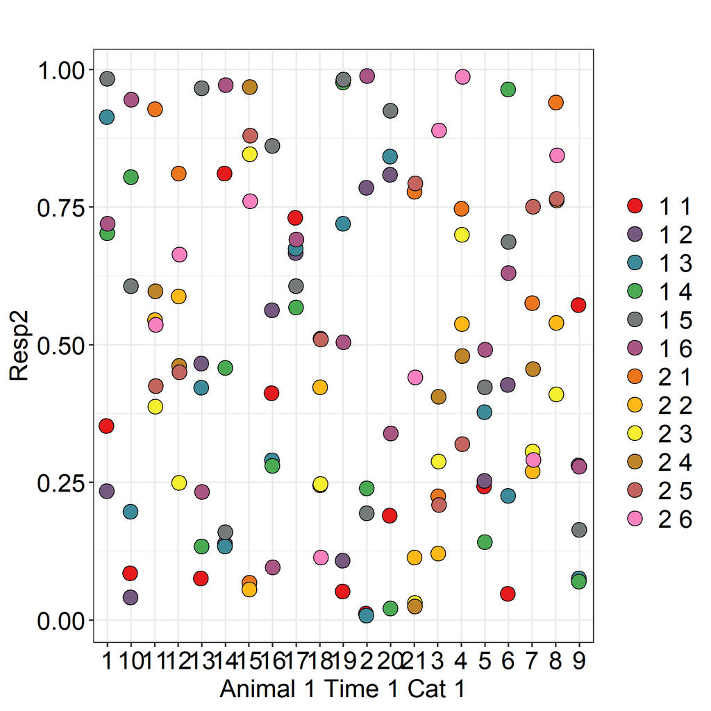

For more information on the theoretical approaches that are implemented within this module, see Bate and Clark (2014).

## References

When referring to InVivoStat, please cite 'InVivoStat, version 5.0'.

Bate, S.T. and Clark, R.A. (2014). The Design and Statistical Analysis of Animal Experiments. Cambridge University Press.

#### R references

R Core Team (2022). R: A language and environment for statistical computing. R Foundation for Statistical Computing, Vienna, Austria. URL https://www.R-project.org/.

Lecoutre, Eric (2003). The R2HTML Package. R News, Vol 3. N. 3, Vienna, Austria.

Schloerke B, Cook D, Larmarange J, Briatte F, Marbach M, Thoen E, Elberg A, Crowley J (2023). GGally: Extension to ggplot2. R package version 2.2.0, https://CRAN.R-project.org/package=GGally.

Neuwirth E (2022). RColorBrewer: ColorBrewer Palettes. R package version 1.1-3, https://CRAN.R-project.org/package=RColorBrewer.

H. Wickham. ggplot2: Elegant Graphics for Data Analysis. Springer-Verlag New York, 2016.

Slowikowski K (2024). ggrepel: Automatically Position Non-Overlapping Text Labels with ggplot2. R package version 0.9.5, https://CRAN.R-project.org/package=ggrepel.

H. Wickham. Reshaping data with the reshape package. Journal of Statistical Software, 21(12), 2007.

Hadley Wickham (2011). The Split-Apply-Combine Strategy for Data Analysis. Journal of Statistical Software, 40(1), 1-29. URL https://www.jstatsoft.org/v40/i01/.

Wickham H, Pedersen T, Seidel D (2023). scales: Scale Functions for Visualization. R package version 1.3.0, https://CRAN.R-project.org/package=scales.

Grothendieck G, Kates L, Petzoldt T (2016). proto: Prototype Object-Based Programming. R package version 1.0.0, https://CRAN.R-project.org/package=proto.

## Analysis dataset

| Observation | Resp2 | Anima 1 | Cat1 | Time 1 |
| --- | --- | --- | --- | --- |
| 1 | 0.353 | 1 | 1 | 1 |
| 2 | 0.234 | 1 | 1 | 2 |
| 3 | 0.914 | 1 | 1 | 3 |
| 4 | 0.703 | 1 | 1 | 4 |
| 5 | 0.983 | 1 | 1 | 5 |
| 6 | 0.720 | 1 | 1 | 6 |
| 7 | 0.225 | 3 | 2 | 1 |
| 8 | 0.121 | 3 | 2 | 2 |
| 9 | 0.288 | 3 | 2 | 3 |
| 10 | 0.406 | 3 | 2 | 4 |
| 11 | 0.209 | 3 | 2 | 5 |
| 12 | 0.889 | 3 | 2 | 6 |
| 13 | 0.076 | 13 | 1 | 1 |
| 14 | 0.466 | 13 | 1 | 2 |
| 15 | 0.422 | 13 | 1 | 3 |
| 16 | 0.134 | 13 | 1 | 4 |
| 17 | 0.966 | 13 | 1 | 5 |
| 18 | 0.233 | 13 | 1 | 6 |
| 19 | 0.012 | 2 | 1 | 1 |
| 20 | 0.785 | 2 | 1 | 2 |
| 21 | 0.008 | 2 | 1 | 3 |
| 22 | 0.239 | 2 | 1 | 4 |
| 23 | 0.194 | 2 | 1 | 5 |
| 24 | 0.988 | 2 | 1 | 6 |
| 25 | 0.747 | 4 | 2 | 1 |
| 26 | 0.538 | 4 | 2 | 2 |
| 27 | 0.700 | 4 | 2 | 3 |
| 28 | 0.480 | 4 | 2 | 4 |
| 29 | 0.320 | 4 | 2 | 5 |
| 30 | 0.987 | 4 | 2 | 6 |

[output cut: 96 more lines]

## Analysis options

Response variable: Resp2

X-axis variable: Anima 1

First categorisation factor: Cat1

Second categorisation factor: Time 1

Categorised gragh style: overlaid

Display legend (Y/N): Y

X-axis title (except for Histogram): Animal 1 Time 1 Cat 1

Y-axis title: Resp2

Error bar type: confidenceinterval

Means with error bar plot type: line

Include observations on Means with SEMs plot (Y/N): N